# Soundscape Inventory Report

Monterey Bay National Marine Sanctuary

2025-02-26

# **What is ocean sound?**

Ocean sound refers to the collection of acoustic energy present in marine environments, encompassing a variety of sources, including sounds from marine animals, geophysical noise from waves, wind, rain, and human generated noise from shipping, sonar, and offshore construction. This collection of sound at a given place and time is often called a soundscape. Monitoring ocean soundscapes provides key insight to understanding ecosystem dynamics, detecting environmental changes, and managing the impacts of noise pollution on marine organisms. Learn more about ocean sounds at [Discovery of Sound in the Sea](https://dosits.org/).

**Why do we care?** Ocean sound is critical for the survival of many marine animals because it is a primary means of communication, orientation and navigation, finding food, avoiding predators, and choosing mates. As such, human activities that produce underwater sounds have the potential to negatively impact animals by reducing their ability to hear prey, predators, and each other. **US National marine sanctuaries** are home to many acoustically active marine animals and understanding the presence and impacts of noise is a conservation priority. Further, the occurrence and types of sounds present offer key insights on animal presence, species behaviors, human-use patterns, and changing ocean conditions.

# **When, where, & why are we listening?**

NOAA’s Office of National Marine Sanctuaries (ONMS) maintains a nationally coordinated underwater sound monitoring network across the National Marine Sanctuary System, known as [ONMS Sound](https://sanctuaries.noaa.gov/science/monitoring/sound/). ONMS sound works with partners to monitor off the US East Coast, in the Gulf of Mexico, off the West Coast and in the Pacific Islands region. Ocean Sound monitoring sites are located in strategic locations within sanctuary boundaries and records continuously. Audio recordings and standardized sound measurements are available through the NOAA National Centers for Environmental Information’s Passive Acoustic Archive. Explore the acoustic monitoring sites [here](https://www.ncei.noaa.gov/maps/passive-acoustic-data/).

The **Monterey Bay National Marine Sanctuary** is one of the largest marine protected areas in the United States, spanning over 6,094 square miles along the central California coast. It is home to a rich diversity of marine life, including whales, sea otters, seabirds, and vast kelp forests. MBNMS supports these ecosystems, promotes marine research, and offers many ocean-based recreational opportunities like diving, fishing, and whale watching.

**Current ocean sound monitoring and analysis** is maintained at four sites within MBNMS. Two sites (MB01, MB02) are located more inshore, capturing more local vessel activity and sounds from nearshore species. The two offshore sites (MB03, MBARI_MARS) capture patterns in migrating whales and transiting commercial vessel traffic.

**Summary of ocean sound monitoring sites**

| Site | Primary.monitoring.purpose | Oceanographic.Setting | Seasonality | Vessel.Traffic.Setting | Latitude | Longitude | Region | Sanctuary | TotalDays | StartDate | Image | NA. | NA..1 | NA..2 | NA..3 | NA..4 | NA..5 | NA..6 | NA..7 | NA..8 | NA..9 | NA..10 | NA..11 | NA..12 |
| --- | --- | --- | --- | --- | --- | --- | --- | --- | --- | --- | --- | --- | --- | --- | --- | --- | --- | --- | --- | --- | --- | --- | --- | --- |
| MB01 | To monitor nearshore patterns in ocean noise | Continental shelf (<200m), near Monterey Bay submarine canyon | Seasonal patterns driven by upwelling, with known sounds from baleen whales and fish | Frequent recreational activity– whale watching and fishing | 36.7980 | -121.9760 | West Coast | MB | 1010 | 2018-11-15 | https://sanctsound.portal.axds.co/#sanctsound/sanctuary/monterey-bay/site/MB01 | NA | NA | NA | NA | NA | NA | NA | NA | NA | NA | NA | NA | NA |
| MB02 | To monitor fish acoustic activity in important commercial and recreational fishing ground | Continental shelf (<200m), adjacent to kelp forest ecosystems | Seasonal patterns driven by upwelling, with known sounds from baleen whales and fish | Frequent recreational activity– whale watching and fishing | 36.6480 | -121.9080 | West Coast | MB | 581 | 2018-11-15 | https://sanctsound.portal.axds.co/#sanctsound/sanctuary/monterey-bay/site/MB02 | NA | NA | NA | NA | NA | NA | NA | NA | NA | NA | NA | NA | NA |
| MB03 | To continue long-history of monitoring trends in ocean ocean noise, including vessel speed reduction | Continental slope (>200m), exposed to deep-water | Seasonal patterns driven by upwelling, with known sounds from baleen whales and dolphins | In the middle of offshore transit lanes for commercial shipping traffic | 36.3703 | -122.3148 | West Coast | MB | 1546 | 2020-10-02 | https://sanctsound.portal.axds.co/#sanctsound/sanctuary/monterey-bay/site/MB03 | NA | NA | NA | NA | NA | NA | NA | NA | NA | NA | NA | NA | NA |
| MBARI-MARS | To monitor trends in marine mammal species presence and behavior and vessel speed reduction | Continental slope (>200m), within submarine canyon | Seasonal patterns driven by upwelling, with known sounds from baleen whales, fish, and dolphins | Distant transiting commercial shipping traffic and nearby research activity | 36.7130 | -122.1860 | West Coast | MB | 2920 | 2015-07-28 | https://www.mbari.org/data/soundscape-visual-browser/ | NA | NA | NA | NA | NA | NA | NA | NA | NA | NA | NA | NA | NA |

# **What sounds contribute to the soundscape?**

Soundscape data are complex – representing all the types of sounds present at a given time and location and influenced by the weather. The purpose of the figure below is to show the contributions to a soundscape: colored lines represent seasonal differences, vertical lines indicate representative frequencies for different sound sources, and the dashed gray lines bound the soundscape to expected range when only wind noise is present.

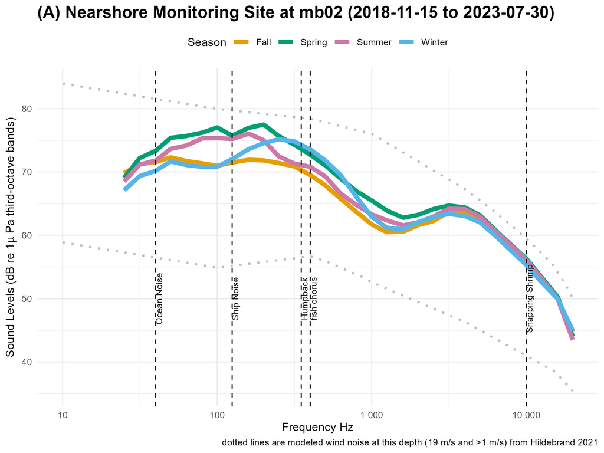

# **What are we learning?**

**Nearshore fish chorus activity**. One of the monitoring sites in Monterey Bay (mb01) is known as a hotspot for fish choruses and a monitoring priority was to understand when fish are acoustically active. A dedicated analysis of the patterns in fish chores was completed to provide initial insight on daily patterns and annual trends. Analysis included data from 2019-2023.

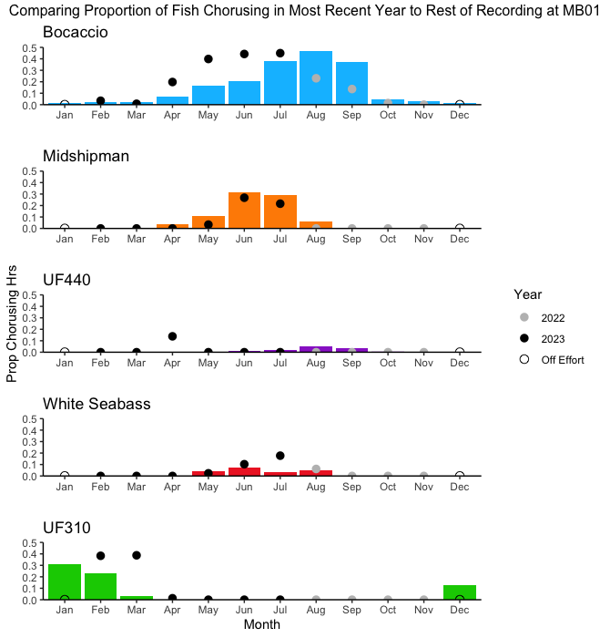

**Figure 3.1: Annual occurrence in fish sounds.** If you want to learn more about other known patterns in acoustic detection of different species, check out [Sanctuary Soundscape Project data portal](https://sanctsound.portal.axds.co/#sanctsound/sanctuary/monterey-bay/site/MB01/method_type/detections).

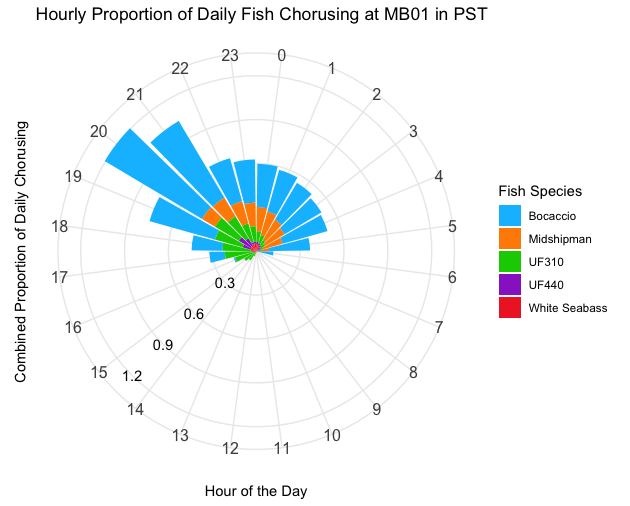

**Figure 3.2: Daily occurrence in fish sounds.**

# Testing scrolling through multiple images

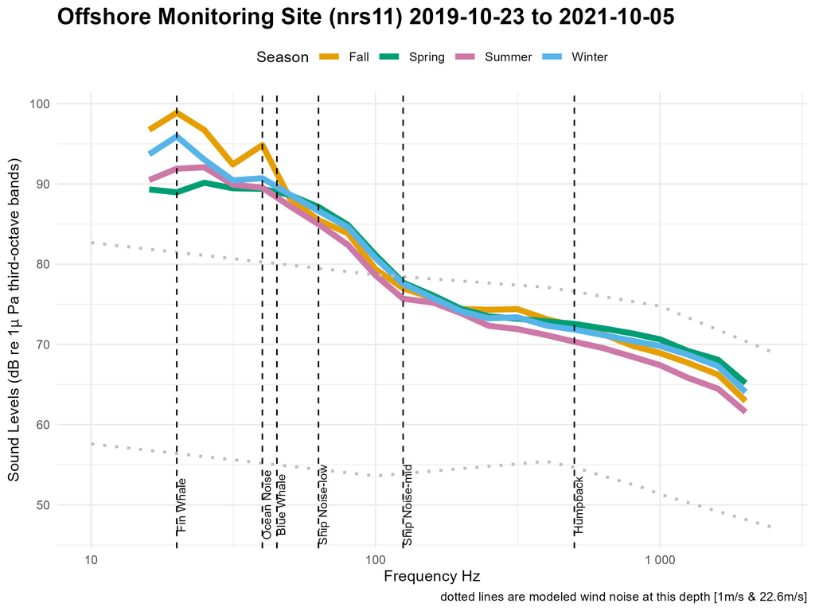

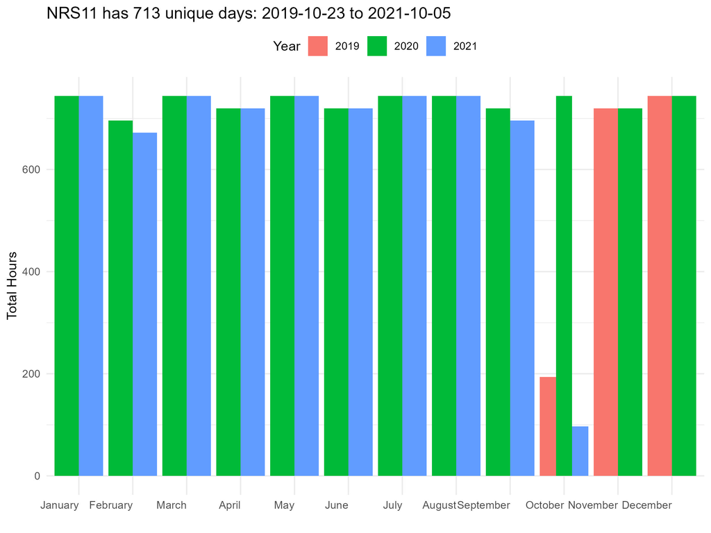